# M5A2AgustinCervantesTenaglia

Agustin Cervantes

15/02/2024

# Actividad Evaluable 2 - Módulo V: Estadística y aprendizaje automático

## Selecciona un conjunto de datos que represente una serie temporal y realiza un análisis de series temporales completo.

Primero importo las librarías que estaré utilizando durante el ejercicio:

```r
suppressMessages(library(tseries))
library(forecast)
library(readxl)
```

### Descripción de la serie temporal

La serie temporal seleccionada fue obtenida de la página de INE (https://www.ine.es/prensa/ipv_tabla1.htm) y contiene los datos del Índice de Precios de Vivienda (IPV) **con una periodicidad trimestral**, con la evolución del índice **desde Junio 2007 a hasta Septiembre 2023**. La tabla fue modificada para reflejar la variación en un índice.

Utilizaremos los datos desde Junio 2007 a hasta Junio 2023 y dejaremos los de Setiembre 2023 apartados para poder compararlo con la predicción que realice el modelo.

```r
datos <- read_excel("C:\\Users\\aguce\\OneDrive\\Desktop\\Dataset_pobl.xlsx",sheet = 1)

prediccion <- read_excel("C:\\Users\\aguce\\OneDrive\\Desktop\\Dataset_pobl.xlsx", sheet = 2)

head(datos)
```

```
## # A tibble: 6 × 2
##   Fecha                Tasa
##   <dttm>              <dbl>
## 1 2007-06-30 00:00:00  102.
## 2 2007-09-30 00:00:00  104.
## 3 2007-12-30 00:00:00  104.
## 4 2008-03-30 00:00:00  105.
## 5 2008-06-30 00:00:00  106.
## 6 2008-09-30 00:00:00  104.
```

#### Creamos la serie temporal para comenzar con el análisis:

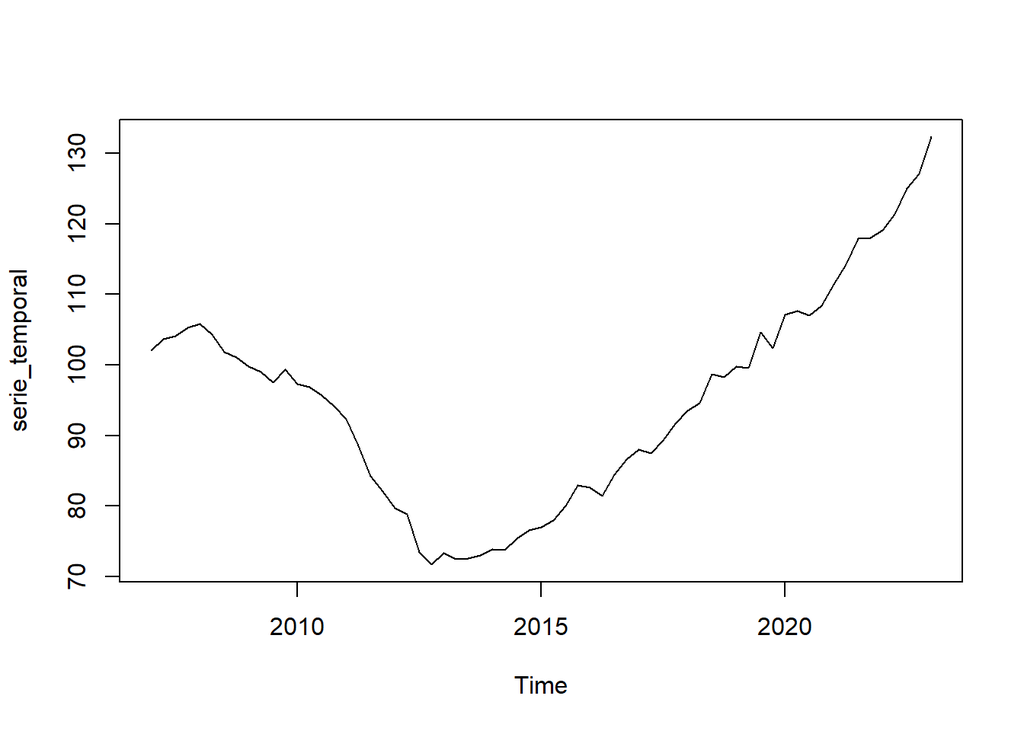

```r
serie_temporal <- ts(datos$Tasa, start = c(2007, 1), frequency = 4)

plot(serie_temporal)
```

## Descomposición de la serie temporal

Generamos la descomposición y vemos el gráfico para analizarlo en detalle:

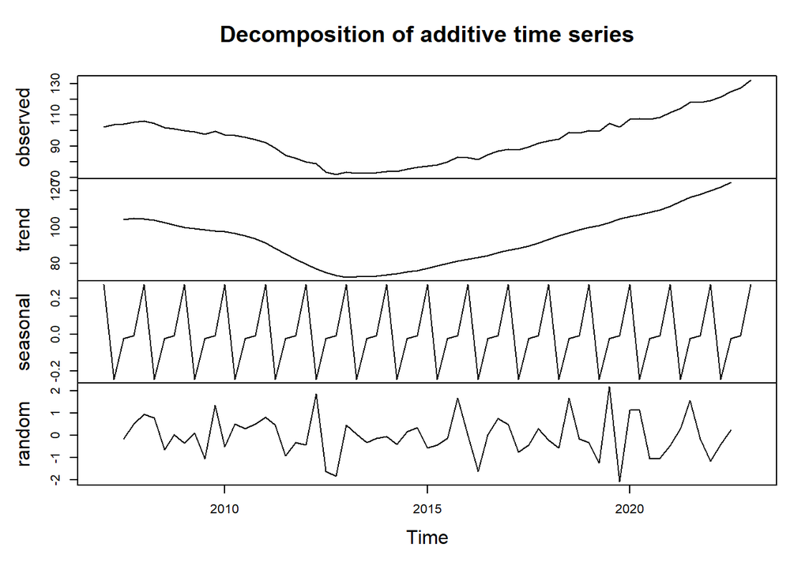

```r
descomposicion <- decompose(serie_temporal)

plot(descomposicion)
```

**Tendencia**: Vemos que la tendencia de la serie temporal es descentente hasta Marzo del año 2013, donde cambia a una tendencia ascendente.

**Fluctuación cíclica**: No es posible identificar fluctuaciones cíclicas en la tendencia.

**Movimientos irregulares**: Es posible identificar variaciones irregulares del índice, pero su amplitud se mantiene entre la franja -2 y 2.

## Análisis de estacionariedad

Para analizar la estacionariedad, utilizo la función del test de Dickey-Fuller:

```r
adf.test(serie_temporal)
```

```
##
##  Augmented Dickey-Fuller Test
##
## data:  serie_temporal
## Dickey-Fuller = -0.51232, Lag order = 3, p-value = 0.9785
## alternative hypothesis: stationary
```

El resultado del testindica que el valor obtenido del estadístico de prueba es -0.51232, con un valor p de 0.9785. Esto sugiere que no hay suficiente evidencia para rechazar la hipótesis nula de que la serie temporal no es estacionaria. En otras palabras, la serie temporal parece ser no estacionaria según este test.

## Ajuste de la serie temporal a un modelo ARIMA

Utilizo la función auto.arima para que seleccione automáticamente el modelo que mejor se ajusta a los datos:

```r
modelo_arima <- auto.arima(serie_temporal)
```

## Análisis de la bondad de ajuste

Para analizar la bondad del ajuste, utilizo la función summary sobre el modelo:

```r
summary(modelo_arima)
```

```
## Series: serie_temporal
## ARIMA(0,2,1)(1,0,0)[4]
##
## Coefficients:
##           ma1    sar1
##       -0.7906  0.2507
## s.e.   0.0855  0.1292
##
## sigma^2 = 3.267:  log likelihood = -126.19
## AIC=258.37   AICc=258.78   BIC=264.8
##
## Training set error measures:
##                     ME     RMSE      MAE       MPE     MAPE     MASE
## Training set 0.1107164 1.751059 1.375119 0.1443016 1.472859 0.240042
##                     ACF1
## Training set -0.09571877
```

ARIMA(0,2,1): No hay componentes autoregresivos no estacionales (AR) en este modelo (orden 0). Se incluye un componente de media móvil (MA) de orden 1 y un componente de integración (I) de orden 2. Además, hay un componente autoregresivo estacional (SAR) de orden 1, con un período estacional de 4 trimestres.Los coeficientes estimados son -0.7906 para el componente de media móvil y 0.2507 para el componente autoregresivo estacional.

Los valores de AIC, AICc y BIC sugieren un buen ajuste del modelo.

## Análisis de los residuos

Analizo los residuos del modelo ARIMA:

```r
residuos <- residuals(modelo_arima)
summary(residuos)
```

```
##    Min. 1st Qu.  Median    Mean 3rd Qu.    Max.
## -3.6577 -0.8886  0.2525  0.1107  1.0721  4.1713
```

Vemos que la mediana y la media son relativamente cercanas, lo que sugiere que los residuos están distribuidos de manera simétrica alrededor de cero. Sin embargo, la presencia de valores muy negativos o positivos indica que puede haber algunas discrepancias entre los valores observados y los valores predichos por el modelo.

## Predicción para un intervalo temporal

Realizo la preducción del modelo para el próximo trimestre de forma gráfica e imprimo el su valor:

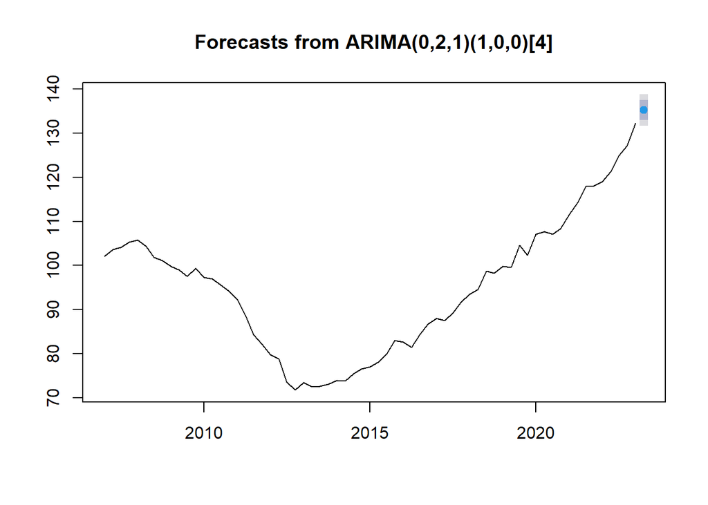

```r
predicciones <- forecast(modelo_arima, h = 1)
plot(predicciones)
```

```r
valor_prediccion <- predicciones$mean
print(valor_prediccion)
```

```
##          Qtr2
## 2023 135.2658
```

Comparo el valor obtenido con el que el real:

```r
head(prediccion)
```

```
## # A tibble: 1 × 2
##   Período             `Tasa anual de vivienda nueva`
##   <dttm>                                       <dbl>
## 1 2023-09-30 00:00:00                           136.
```

Error del modelo = 135.6266 - 135.2658 = 0,3608

**Esto implica que el error del modelo en esta predicción fue del 0,27%**

## Investiga qué tipo de modelos predictivos de series temporales se utilizan en el ámbito de los datos que has elegido. Busca una función en R e implementa estimación y predicción.

En función de lo investigado, una alternativa podría ser un modelo de suavizado exponencial, como el método de Holt-Winters. Este método es útil cuando hay presencia de tendencia y estacionalidad en la serie temporal:

```r
modelo_hw <- HoltWinters(serie_temporal)

prediccion_hw <- predict(modelo_hw, n.ahead = 1)

valor_predicho_hw <- prediccion_hw[length(prediccion_hw)]

print(valor_predicho_hw)
```

```
## [1] 134.6003
```

Error del modelo = 135.6266 - 134.6003 = 1,0263. Lo que implica que el error del modelo en esta predicción fue del 0,76%.